# HW3. Тестирование гипотез. t-test. Корреляции

### 3.2 График плотности по категориям

Интересно, какие категории слов дети осваивают раньше? Ниже приведен график плотности значений переменной `CumulOtherWords` по группам `BroadCategory`. Он, например, показывает, что количество ранее освоенных слов в категории `games & routines` растет быстрее, чем слов в категории `predicates`. Это может говорить о том, что слова, относящиеся к играм и ежедневным занятиям (*я спрятался*, *умываться*) дети осваивают раньше, чем более абстрактные глаголы (например, *купить* или *думать*)

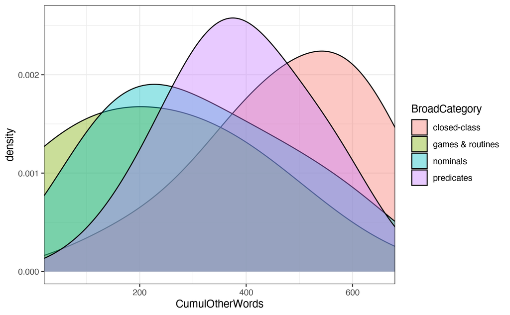

Ваша задача - с помощью ggplot визуализировать график возраста освоения слов (Age of Acquisition) по группам BroadCategory, тема - `theme_bw`. В геоме плотности используйте аргумент сглаживания adjust со значением 2. Подпишите оси и график понятным читателю образом. В комментарии приведен пример использования функции `scale_x_continuous` в ggplot. С ее помощью подпишите ось X так, чтобы была ясна разбивка по полугоду (то есть 12, 18 месяцев и т. д.).

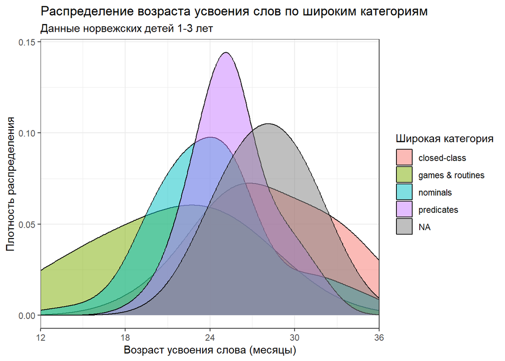

```r
library(ggplot2)
ggplot(Norwegian_data, aes(x = AgeOfAcq, fill = BroadCategory)) +
      geom_density(alpha = 0.5, adjust = 2) +
      scale_x_continuous(
        expand = c(0, 0),
        breaks = seq(0, 36, by = 6),
        limits = c(12, 36)) +
      theme_bw() +
      labs(
      title = "Распределение возраста усвоения слов по широким категориям",
      subtitle = "Данные норвежских детей 1-3 лет",
      x = "Возраст усвоения слова (месяцы)",
      y = "Плотность распределения",
      fill = "Широкая категория" )
```

### 3.3 Интерпретация графика плотности

[output not shown]

### 3.4 Возраст освоения VS кумулятивное количество ранее освоенных слов

Постройте график рассеяния по переменным `AgeOfAcq` и `CumulOtherWords`, как показано ниже. Здесь использован геом `geom_count` с разбросом точек (jitter) и прозрачностью 0.5. Палитра - базовая. Предварительно, удалите из данных строки, для которых не указана `BroadCategory` (NA).

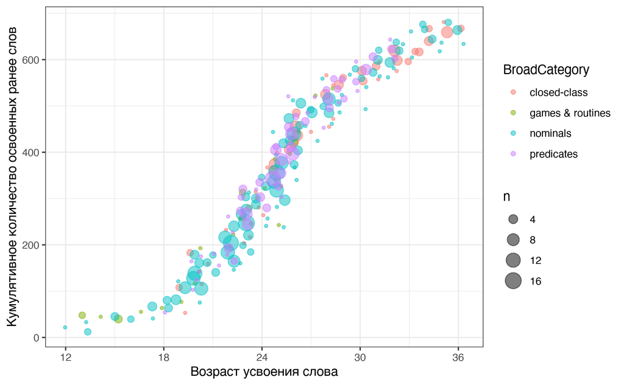

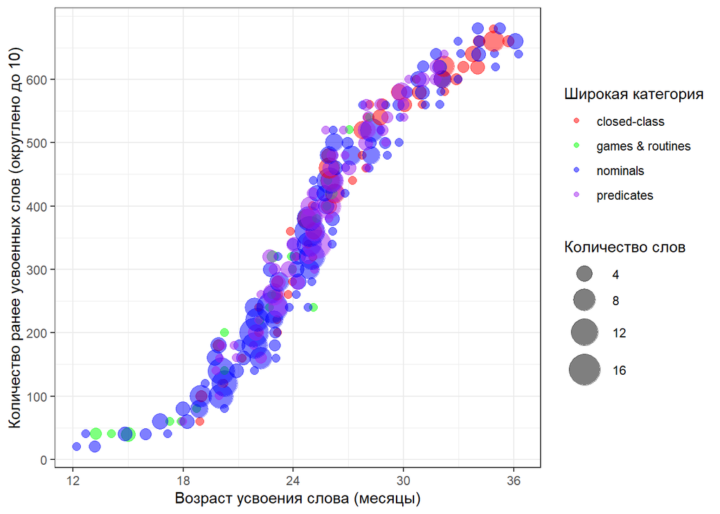

```r
Norwegian_data_clean <- Norwegian_data[!is.na(Norwegian_data$BroadCategory), ]

ggplot(Norwegian_data_clean, aes(x = AgeOfAcq, y = CumulOtherWords, color = BroadCategory)) +
  geom_count(alpha = 0.5, position = position_jitter(width = 0.3, height = 0.3)) +
  scale_x_continuous(name = "Возраст усвоения слова (месяцы)",
                    breaks = seq(12, 36, by = 6)) +
  scale_y_continuous(name = "Количество ранее усвоенных слов (округлено до 10)", breaks = seq(0, max(Norwegian_data_clean$CumulOtherWords, na.rm = TRUE), by = 100)) +
  scale_size_area(name = "Количество слов",max_size = 10,breaks = c(4, 8, 12, 16)) +
  scale_color_manual(name = "Широкая категория",
    values = c(
      "closed-class" = "red",
      "games & routines" = "green",
      "nominals" = "blue",
      "predicates" = "purple")) +
  theme_bw()
```

### 3.5 Условия для проведения корреляционного анализа

Условием для проведения корреляционного анализа Пирсона является нормальное распределение данных.  
Раскомментируйте код ниже, чтобы визуально оценить нормальность распределения переменной `AgeOfAcq` по графику QQ-plot (quantile-quantile plot). Данные откладываются по оси y, а по оси x откладываются значения, которые бы данные имели, если бы они были идеально нормальными (теоретические квантили). Если данные в выборке нормально распределены, все точки будут лежать на прямой. Полоса вокруг прямой показывает 95% доверительный интервал: если практически все точки попадают в этот интервал, это сильное свидетельство в пользу того, что данные в выборке распределены нормально. Данные распределены ненормально, если они образуют ломаный или сильно изогнутый паттерн, а также если они далеко отходят от прямой в той или иной области.

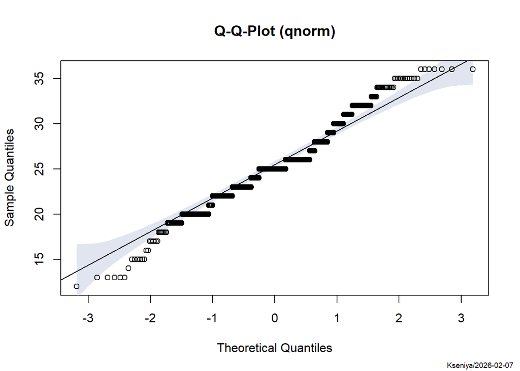

```r
library(DescTools)
PlotQQ(Norwegian_data$AgeOfAcq)
```

Постройте QQ-plot для переменной `CumulOtherWords`.

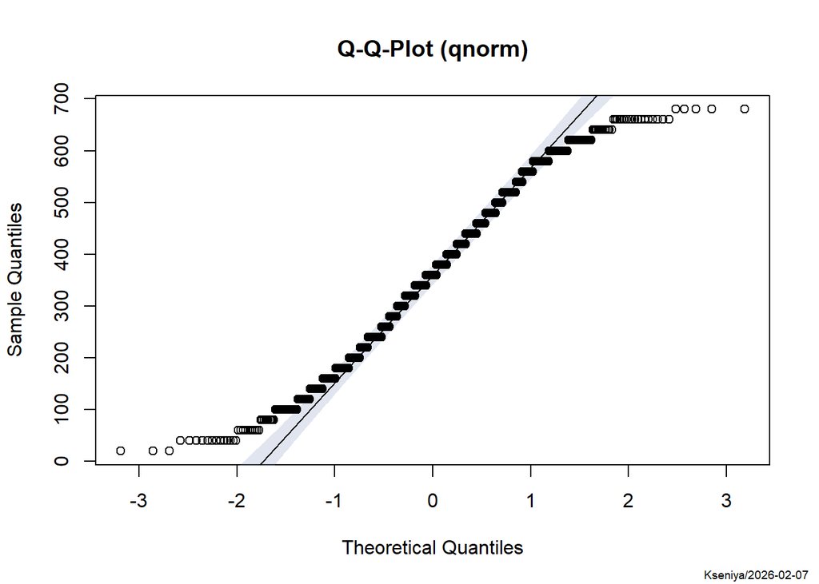

```r
PlotQQ(Norwegian_data$CumulOtherWords)
```

### 3.6 Корреляция `AgeOfAcq` и `CumulOtherWords`

С помощью функции cor.test проведите корреляционный анализ. Ваши выводы из предыдущего пункта (3.5) подскажут, какой метод вы должны использовать.

```r
cor_pearson <- cor.test(Norwegian_data$AgeOfAcq,
                        Norwegian_data$CumulOtherWords,
                        method = "pearson",
                        conf.level = 0.95)
cor_pearson
```

```
##
##  Pearson's product-moment correlation
##
## data:  Norwegian_data$AgeOfAcq and Norwegian_data$CumulOtherWords
## t = 92.832, df = 693, p-value < 2.2e-16
## alternative hypothesis: true correlation is not equal to 0
## 95 percent confidence interval:
##  0.9561038 0.9672313
## sample estimates:
##       cor
## 0.9620656
```

### 3.7 Интерпретация результатов теста

```
Статистические результаты:
- Коэффициент корреляции Пирсона: r = 0.9621
- t-статистика: t(693) = 92.832
- Степени свободы: df = 693
- p-value: p < 2.2e-16 (практически 0)

1) Крайне высокий уровень значимости -> вероятность получить такую сильную корреляцию случайно (при отсутствии реальной связи в генеральной совокупности) практически равна нулю.
2) Коэффициент r = 0.9621 очень близок к 1
3) Большое количество степеней свободы (df = 693) повышает надежность теста
4) Доверительный интервал очень узкий и полностью лежит в области высоких положительных значений

Общий вывод: Чем старше ребенок, тем больше слов он уже знает к моменту усвоения нового слова
```

### 3.8 Степень свободы

Сравните количество строк в датасете, по которому проводился корреляционный анализ, и степень свободы (df), указанную в результатах теста. Как получилось число df?

```
Количество строк: 695
Степень свободы: 693

По формуле степеней свободы в корреляции Пирсона:
df = n - 2
n = df + 2 = 693 + 2 = 695
```